# Multi-Class Classification Model for Crop Mapping in Canada Using Scikit-Learn Take 2

### July 10, 2020

Template Credit: Adapted from a template made available by Dr. Jason Brownlee of Machine Learning Mastery. [https://machinelearningmastery.com/]

SUMMARY: The purpose of this project is to construct a predictive model using various machine learning algorithms and to document the end-to-end steps using a template. The Crop Mapping in Canada dataset is a multi-class classification situation where we are trying to predict one of several (more than two) possible outcomes.

INTRODUCTION: This data set is a fused bi-temporal optical-radar data for cropland classification. The organization collected the images using RapidEye satellites (optical) and the Unmanned Aerial Vehicle Synthetic Aperture Radar (UAVSAR) system (Radar) over an agricultural region near Winnipeg, Manitoba, Canada in 2012. There are 2 *49 radar features and 2* 38 optical features for two dates: 05 and 14 July 2012. Seven crop type classes exist for this data set as follows: 1-Corn; 2-Peas; 3-Canola; 4-Soybeans; 5-Oats; 6-Wheat; and 7-Broadleaf.

In iteration Take1, we constructed and tuned machine learning models for this dataset using the Scikit-Learn library. We also observed the best accuracy result that we could obtain using the tuned models with the training and test datasets.

In this Take2 iteration, we will construct and tune machine learning models for this dataset using the XGBoost. We will observe the best accuracy result that we can obtain using the tuned models with the training and test datasets.

ANALYSIS: From iteration Take1, the baseline performance of the machine learning algorithms achieved an average accuracy of 94.87%. Two algorithms (Extra Trees and Random Forest) achieved the top accuracy metrics after the first round of modeling. After a series of tuning trials, Extra Trees turned in a better overall result. Extra Trees achieved an accuracy metric of 99.71%. When configured with the optimized parameters, the Extra Trees model processed the testing dataset with an accuracy of 99.74%, which was even better than the prediction accuracy from the training data.

From this Take2 iteration, the performance of the XGBoost model achieved an accuracy score of 99.82%. After a series of tuning trials, the XGBoost model processed the test dataset with an accuracy score of 99.84%, which was consistent with the training result.

CONCLUSION: For this iteration, the XGBoost model achieved the best overall results using the training and test datasets. For this dataset, we should consider using the XGBoost algorithm for further modeling.

Dataset Used: Crop Mapping in Canada Data Set

Dataset ML Model: Multi-Class classification with numerical attributes

Dataset Reference: https://archive.ics.uci.edu/ml/datasets/Crop+mapping+using+fused+optical-radar+data+set

Any predictive modeling machine learning project generally can be broken down into about six major tasks:

1. Prepare Environment
2. Summarize and Visualize Data
3. Pre-process Data
4. Train and Evaluate Models
5. Fine-tune and Improve Models
6. Finalize Model and Present Analysis

## Task 1 - Prepare Environment

```python
# Install the necessary packages for Colab
!pip install python-dotenv PyMySQL
```

```python
# Retrieve the GPU information from Colab
gpu_info = !nvidia-smi
gpu_info = '\n'.join(gpu_info)
if gpu_info.find('failed') >= 0:
    print('Select the Runtime → "Change runtime type" menu to enable a GPU accelerator, ')
    print('and then re-execute this cell.')
else:
    print(gpu_info)
```

```
Wed Jul  8 14:52:29 2020
+-----------------------------------------------------------------------------+
| NVIDIA-SMI 450.36.06    Driver Version: 418.67       CUDA Version: 10.1     |
|-------------------------------+----------------------+----------------------+
| GPU  Name        Persistence-M| Bus-Id        Disp.A | Volatile Uncorr. ECC |
| Fan  Temp  Perf  Pwr:Usage/Cap|         Memory-Usage | GPU-Util  Compute M. |
|                               |                      |               MIG M. |
|===============================+======================+======================|
|   0  Tesla P100-PCIE...  Off  | 00000000:00:04.0 Off |                    0 |
| N/A   41C    P0    27W / 250W |      0MiB / 16280MiB |      0%      Default |
|                               |                      |                 ERR! |
+-------------------------------+----------------------+----------------------+

+-----------------------------------------------------------------------------+
| Processes:                                                                  |
|  GPU   GI   CI        PID   Type   Process name                  GPU Memory |
|        ID   ID                                                   Usage      |
|=============================================================================|
|  No running processes found                                                 |
+-----------------------------------------------------------------------------+
```

```python
# Retrieve the memory configuration from Colab
from psutil import virtual_memory
ram_gb = virtual_memory().total / 1e9
print('Your runtime has {:.1f} gigabytes of available RAM\n'.format(ram_gb))

if ram_gb < 20:
    print('To enable a high-RAM runtime, select the Runtime → "Change runtime type"')
    print('menu, and then select High-RAM in the Runtime shape dropdown. Then, ')
    print('re-execute this cell.')
else:
    print('You are using a high-RAM runtime!')
```

```
Your runtime has 13.7 gigabytes of available RAM

To enable a high-RAM runtime, select the Runtime → "Change runtime type"
menu, and then select High-RAM in the Runtime shape dropdown. Then,
re-execute this cell.
```

```python
# Retrieve the CPU information
ncpu = !nproc
print("The number of available CPUs is:", ncpu[0])
```

```
The number of available CPUs is: 2
```

### 1.a) Load libraries and modules

```python
# Set the random seed number for reproducible results
seedNum = 888
```

```python
import numpy as np
import pandas as pd
import matplotlib.pyplot as plt
import os
import sys
import math
import smtplib
import boto3
from datetime import datetime
from dotenv import load_dotenv
from sklearn import preprocessing
from sklearn.model_selection import train_test_split
from sklearn.model_selection import KFold
from sklearn.model_selection import StratifiedKFold
from sklearn.model_selection import cross_val_score
from sklearn.model_selection import GridSearchCV
from sklearn.metrics import classification_report
from sklearn.metrics import confusion_matrix
from sklearn.metrics import accuracy_score
from xgboost import XGBClassifier
```

### 1.b) Set up the controlling parameters and functions

```python
# Begin the timer for the script processing
startTimeScript = datetime.now()

# Set up the number of CPU cores available for multi-thread processing
n_jobs = 1

# Set up the flag to stop sending progress emails (setting to True will send status emails!)
notifyStatus = False

# Set up the parent directory location for loading the dotenv files
useGDrive = False
if useGDrive:
    # Mount Google Drive locally for storing files
    from google.colab import drive
    drive.mount('/content/gdrive')
    gdrivePrefix = '/content/gdrive/My Drive/Colab_Downloads/'
    env_path = '/content/gdrive/My Drive/Colab Notebooks/'
    dotenv_path = env_path + "python_script.env"
    load_dotenv(dotenv_path=dotenv_path)

# Set up the dotenv file for retrieving environment variables
useLocalPC = False
if useLocalPC:
    env_path = "/Users/david/PycharmProjects/"
    dotenv_path = env_path + "python_script.env"
    load_dotenv(dotenv_path=dotenv_path)

# Configure the plotting style
plt.style.use('seaborn')

# Set Pandas options
pd.set_option("display.max_rows", 500)
pd.set_option("display.width", 140)

# Set the flag for splitting the dataset
splitDataset = True
splitPercentage = 0.25

# Set the number of folds for cross validation
n_folds = 5

# Set various default modeling parameters
scoring = 'accuracy'
```

```python
# Set up the email notification function
def status_notify(msg_text):
    access_key = os.environ.get('SNS_ACCESS_KEY')
    secret_key = os.environ.get('SNS_SECRET_KEY')
    aws_region = os.environ.get('SNS_AWS_REGION')
    topic_arn = "arn:aws:sns:us-east-1:072417399597:PythonMLScriptNotification"
    if (access_key is None) or (secret_key is None) or (aws_region is None):
        sys.exit("Incomplete notification setup info. Script Processing Aborted!!!")
    sns = boto3.client('sns', aws_access_key_id=access_key, aws_secret_access_key=secret_key, region_name=aws_region)
    response = sns.publish(TopicArn=topic_arn, Message=msg_text)
    if response['ResponseMetadata']['HTTPStatusCode'] != 200 :
        print('Status notification not OK with HTTP status code:', response['ResponseMetadata']['HTTPStatusCode'])
```

```python
if notifyStatus: status_notify("Task 1 - Prepare Environment has begun! " + datetime.now().strftime('%a %B %d, %Y %I:%M:%S %p'))
```

### 1.c) Load dataset

```python
dataset_path = 'https://dainesanalytics.com/datasets/crop-mapping-winnipeg/WinnipegDataset.txt'
Xy_original = pd.read_csv(dataset_path)

# Take a peek at the dataframe after import
Xy_original.head(10)
```

|  | label | f1 | f2 | f3 | f4 | f5 | f6 | f7 | f8 | f9 | f10 | f11 | f12 | f13 | f14 | f15 | f16 | f17 | f18 | f19 | f20 | f21 | f22 | f23 | f24 | f25 | f26 | f27 | f28 | … |
| --- | --- | --- | --- | --- | --- | --- | --- | --- | --- | --- | --- | --- | --- | --- | --- | --- | --- | --- | --- | --- | --- | --- | --- | --- | --- | --- | --- | --- | --- | --- |
| 0 | 1 | -13.559 | -21.407 | -11.4040 | -15.248 | -11.923 | -15.291 | -2.1548 | -7.8474 | -10.0020 | 0.04239 | 3.3253 | 3.3677 | 0.35631 | 0.058490 | 0.58520 | 0.24150 | 0.51934 | 0.23916 | -0.62424 | -0.81493 | -0.70844 | -0.65641 | -0.19568 | -0.63160 | 0.091945 | 0.026703 | 0.005017 | 0.62019 | … |
| 1 | 1 | -12.802 | -20.335 | -10.3990 | -14.132 | -11.096 | -14.361 | -2.4039 | -7.5330 | -9.9369 | 0.22842 | 3.0360 | 3.2644 | 0.34295 | 0.060525 | 0.59652 | 0.25249 | 0.50796 | 0.23955 | -0.57229 | -0.74854 | -0.64839 | -0.62810 | -0.18825 | -0.55448 | 0.115710 | 0.031183 | 0.006051 | 0.60356 | … |
| 2 | 1 | -12.431 | -19.902 | -10.0740 | -13.598 | -10.829 | -14.048 | -2.3566 | -7.4717 | -9.8283 | 0.44978 | 2.7687 | 3.2185 | 0.34489 | 0.061731 | 0.59338 | 0.26362 | 0.49870 | 0.23768 | -0.53347 | -0.70253 | -0.58846 | -0.61836 | -0.17804 | -0.48642 | 0.127130 | 0.032382 | 0.006162 | 0.58683 | … |
| 3 | 1 | -12.689 | -19.529 | -10.0280 | -13.350 | -11.056 | -14.014 | -2.6611 | -6.8396 | -9.5006 | 0.66378 | 2.2942 | 2.9580 | 0.32760 | 0.067825 | 0.60457 | 0.28135 | 0.47717 | 0.24148 | -0.50405 | -0.66998 | -0.52543 | -0.61169 | -0.17507 | -0.43576 | 0.127200 | 0.031091 | 0.006040 | 0.57769 | … |
| 4 | 1 | -12.686 | -19.278 | -9.8185 | -13.108 | -10.932 | -13.939 | -2.8675 | -6.5919 | -9.4594 | 0.83143 | 2.1756 | 3.0070 | 0.31701 | 0.069483 | 0.61351 | 0.28768 | 0.47476 | 0.23756 | -0.50314 | -0.68221 | -0.50731 | -0.59134 | -0.17505 | -0.45195 | 0.131550 | 0.031960 | 0.006439 | 0.57937 | … |
| 5 | 1 | -12.478 | -19.034 | -9.6201 | -12.888 | -10.761 | -13.687 | -2.8583 | -6.5555 | -9.4138 | 0.79854 | 2.1276 | 2.9261 | 0.31723 | 0.070118 | 0.61265 | 0.28867 | 0.47115 | 0.24018 | -0.49984 | -0.69457 | -0.50160 | -0.58093 | -0.17393 | -0.45870 | 0.138010 | 0.033254 | 0.006886 | 0.57967 | … |
| 6 | 1 | -12.459 | -19.019 | -9.3854 | -12.766 | -10.664 | -13.393 | -3.0739 | -6.5599 | -9.6338 | 0.62733 | 2.1023 | 2.7297 | 0.30766 | 0.067934 | 0.62440 | 0.28668 | 0.46519 | 0.24812 | -0.45483 | -0.64691 | -0.47553 | -0.51887 | -0.15984 | -0.42968 | 0.145800 | 0.031903 | 0.006798 | 0.55627 | … |
| 7 | 1 | -12.721 | -19.057 | -9.4054 | -12.887 | -10.797 | -13.384 | -3.3153 | -6.3366 | -9.6519 | 0.49645 | 2.0904 | 2.5868 | 0.29604 | 0.068815 | 0.63515 | 0.28488 | 0.46100 | 0.25411 | -0.42858 | -0.60544 | -0.45454 | -0.48445 | -0.15522 | -0.41000 | 0.144320 | 0.029664 | 0.006563 | 0.54273 | … |
| 8 | 1 | -12.777 | -19.202 | -9.2785 | -12.905 | -10.762 | -13.213 | -3.4982 | -6.4252 | -9.9234 | 0.30780 | 2.1437 | 2.4515 | 0.28855 | 0.065722 | 0.64572 | 0.28013 | 0.45891 | 0.26096 | -0.39564 | -0.58572 | -0.44087 | -0.44121 | -0.14412 | -0.38875 | 0.148360 | 0.028158 | 0.006335 | 0.52267 | … |
| 9 | 1 | -12.804 | -19.273 | -9.2722 | -12.937 | -10.802 | -13.143 | -3.5322 | -6.4682 | -10.0000 | 0.20590 | 2.1353 | 2.3412 | 0.28728 | 0.064787 | 0.64793 | 0.27865 | 0.45561 | 0.26575 | -0.37654 | -0.55633 | -0.43470 | -0.42874 | -0.13967 | -0.36161 | 0.149380 | 0.027014 | 0.006100 | 0.50998 | … |

10 rows × 175 columns

```python
Xy_original.info(verbose=True)
```

```
<class 'pandas.core.frame.DataFrame'>
RangeIndex: 325834 entries, 0 to 325833
Data columns (total 175 columns):
 #   Column  Dtype
---  ------  -----
 0   label   int64
 1   f1      float64
 2   f2      float64
 3   f3      float64
 4   f4      float64
 5   f5      float64
 6   f6      float64
 7   f7      float64
 8   f8      float64
 9   f9      float64
```

[output cut: 167 more lines]

```python
Xy_original.describe()
```

|  | label | f1 | f2 | f3 | f4 | f5 | f6 | f7 | f8 | f9 | f10 | f11 | f12 | f13 | f14 | f15 | f16 | f17 | f18 | f19 | f20 | f21 | f22 | f23 | f24 | f25 | f26 | f27 | f28 | … |
| --- | --- | --- | --- | --- | --- | --- | --- | --- | --- | --- | --- | --- | --- | --- | --- | --- | --- | --- | --- | --- | --- | --- | --- | --- | --- | --- | --- | --- | --- | --- |
| count | 325834.000000 | 325834.000000 | 325834.000000 | 325834.000000 | 325834.00000 | 325834.000000 | 325834.000000 | 325834.000000 | 325834.000000 | 325834.000000 | 325834.000000 | 325834.000000 | 325834.000000 | 325834.000000 | 325834.000000 | 325834.000000 | 325834.000000 | 325834.000000 | 325834.000000 | 325834.000000 | 325834.000000 | 325834.000000 | 325834.000000 | 325834.000000 | 325834.000000 | 325834.000000 | 325834.000000 | 325834.000000 | 325834.000000 | … |
| mean | 4.062421 | -15.143602 | -24.026035 | -15.400034 | -18.59383 | -14.493472 | -18.427329 | 0.256432 | -8.882434 | -8.626002 | -0.166500 | 4.100357 | 3.933857 | 0.480376 | 0.064088 | 0.455535 | 0.217800 | 0.555515 | 0.226686 | -1.517263 | -1.608698 | -1.181434 | -1.592702 | -0.308595 | -1.486840 | 0.057962 | 0.025120 | 0.005054 | 0.715467 | … |
| std | 1.604617 | 3.504255 | 4.054214 | 3.267857 | 3.71163 | 3.189013 | 3.675741 | 1.682060 | 1.204040 | 2.002658 | 0.596276 | 1.499603 | 1.539068 | 0.083552 | 0.020465 | 0.093410 | 0.041863 | 0.082040 | 0.045401 | 0.644197 | 0.621884 | 0.519517 | 0.668061 | 0.155145 | 0.635231 | 0.054490 | 0.020026 | 0.005420 | 0.067356 | … |
| min | 1.000000 | -23.971000 | -34.308000 | -23.161000 | -27.24500 | -22.103000 | -26.897000 | -5.582600 | -16.389000 | -16.558000 | -2.717500 | -4.281900 | -4.498300 | 0.209190 | 0.015586 | 0.162270 | 0.064580 | 0.153900 | 0.075863 | -6.793300 | -7.756700 | -7.643300 | -7.676600 | -2.051400 | -7.383900 | 0.006389 | 0.003183 | 0.000264 | 0.307150 | … |
| 25% | 3.000000 | -17.848000 | -27.119000 | -17.563000 | -21.44900 | -16.989000 | -21.450000 | -1.037800 | -9.658500 | -10.070000 | -0.526397 | 3.141300 | 2.933200 | 0.415260 | 0.048986 | 0.382610 | 0.189580 | 0.502630 | 0.198030 | -1.835700 | -1.917375 | -1.436000 | -1.957400 | -0.386190 | -1.786200 | 0.022808 | 0.010740 | 0.001502 | 0.679390 | … |
| 50% | 4.000000 | -15.992000 | -25.064000 | -16.164000 | -19.58800 | -15.099000 | -19.282000 | 0.309180 | -8.915900 | -8.733100 | -0.174610 | 4.078600 | 3.958250 | 0.483265 | 0.061419 | 0.450350 | 0.216770 | 0.556410 | 0.224160 | -1.424200 | -1.496500 | -1.082600 | -1.509800 | -0.277290 | -1.377200 | 0.034611 | 0.016227 | 0.002560 | 0.718200 | … |
| 75% | 6.000000 | -11.786000 | -20.387000 | -13.427000 | -15.65000 | -11.735000 | -15.514000 | 1.558200 | -8.190200 | -7.158100 | 0.171758 | 5.089700 | 4.879600 | 0.548218 | 0.074158 | 0.529400 | 0.245190 | 0.612260 | 0.255760 | -1.084300 | -1.177800 | -0.836522 | -1.142900 | -0.202810 | -1.058800 | 0.078199 | 0.036190 | 0.007400 | 0.761590 | … |
| max | 7.000000 | 2.535600 | -7.589100 | 1.104000 | 0.77491 | -0.887390 | 0.951780 | 7.029900 | -1.175400 | -0.924610 | 3.784800 | 11.212000 | 10.452000 | 0.818920 | 0.271850 | 0.756480 | 0.437000 | 0.853710 | 0.433590 | -0.209890 | -0.374020 | -0.123950 | -0.231290 | -0.027539 | -0.200370 | 2.444500 | 0.762620 | 0.112550 | 0.929370 | … |

8 rows × 175 columns

```python
Xy_original.isnull().sum()
```

```
label    0
f1       0
f2       0
f3       0
f4       0
f5       0
f6       0
f7       0
f8       0
f9       0
f10      0
f11      0
f12      0
f13      0
f14      0
f15      0
f16      0
f17      0
f18      0
f19      0
f20      0
f21      0
f22      0
f23      0
f24      0
f25      0
f26      0
f27      0
f28      0
f29      0
f30      0
f31      0
f32      0
f33      0
f34      0
f35      0
f36      0
f37      0
f38      0
f39      0
```

[output cut: 121 more lines]

```
f161     0
f162     0
f163     0
f164     0
f165     0
f166     0
f167     0
f168     0
f169     0
f170     0
f171     0
f172     0
f173     0
f174     0
dtype: int64
```

```python
print('Total number of NaN in the dataframe: ', Xy_original.isnull().sum().sum())
```

```
Total number of NaN in the dataframe:  0
```

### 1.d) Data Cleaning

```python
# Standardize the class column to the name of targetVar if required
Xy_original = Xy_original.rename(columns={'label': 'targetVar'})

# Convert columns from one data type to another
Xy_original['f137'] = Xy_original['f137'].astype('float')
Xy_original['f138'] = Xy_original['f138'].astype('float')
Xy_original['f139'] = Xy_original['f139'].astype('float')
Xy_original['f140'] = Xy_original['f140'].astype('float')
Xy_original['f141'] = Xy_original['f141'].astype('float')

# Take a peek at the dataframe after cleaning
Xy_original.head(10)
```

|  | targetVar | f1 | f2 | f3 | f4 | f5 | f6 | f7 | f8 | f9 | f10 | f11 | f12 | f13 | f14 | f15 | f16 | f17 | f18 | f19 | f20 | f21 | f22 | f23 | f24 | f25 | f26 | f27 | f28 | … |
| --- | --- | --- | --- | --- | --- | --- | --- | --- | --- | --- | --- | --- | --- | --- | --- | --- | --- | --- | --- | --- | --- | --- | --- | --- | --- | --- | --- | --- | --- | --- |
| 0 | 1 | -13.559 | -21.407 | -11.4040 | -15.248 | -11.923 | -15.291 | -2.1548 | -7.8474 | -10.0020 | 0.04239 | 3.3253 | 3.3677 | 0.35631 | 0.058490 | 0.58520 | 0.24150 | 0.51934 | 0.23916 | -0.62424 | -0.81493 | -0.70844 | -0.65641 | -0.19568 | -0.63160 | 0.091945 | 0.026703 | 0.005017 | 0.62019 | … |
| 1 | 1 | -12.802 | -20.335 | -10.3990 | -14.132 | -11.096 | -14.361 | -2.4039 | -7.5330 | -9.9369 | 0.22842 | 3.0360 | 3.2644 | 0.34295 | 0.060525 | 0.59652 | 0.25249 | 0.50796 | 0.23955 | -0.57229 | -0.74854 | -0.64839 | -0.62810 | -0.18825 | -0.55448 | 0.115710 | 0.031183 | 0.006051 | 0.60356 | … |
| 2 | 1 | -12.431 | -19.902 | -10.0740 | -13.598 | -10.829 | -14.048 | -2.3566 | -7.4717 | -9.8283 | 0.44978 | 2.7687 | 3.2185 | 0.34489 | 0.061731 | 0.59338 | 0.26362 | 0.49870 | 0.23768 | -0.53347 | -0.70253 | -0.58846 | -0.61836 | -0.17804 | -0.48642 | 0.127130 | 0.032382 | 0.006162 | 0.58683 | … |
| 3 | 1 | -12.689 | -19.529 | -10.0280 | -13.350 | -11.056 | -14.014 | -2.6611 | -6.8396 | -9.5006 | 0.66378 | 2.2942 | 2.9580 | 0.32760 | 0.067825 | 0.60457 | 0.28135 | 0.47717 | 0.24148 | -0.50405 | -0.66998 | -0.52543 | -0.61169 | -0.17507 | -0.43576 | 0.127200 | 0.031091 | 0.006040 | 0.57769 | … |
| 4 | 1 | -12.686 | -19.278 | -9.8185 | -13.108 | -10.932 | -13.939 | -2.8675 | -6.5919 | -9.4594 | 0.83143 | 2.1756 | 3.0070 | 0.31701 | 0.069483 | 0.61351 | 0.28768 | 0.47476 | 0.23756 | -0.50314 | -0.68221 | -0.50731 | -0.59134 | -0.17505 | -0.45195 | 0.131550 | 0.031960 | 0.006439 | 0.57937 | … |
| 5 | 1 | -12.478 | -19.034 | -9.6201 | -12.888 | -10.761 | -13.687 | -2.8583 | -6.5555 | -9.4138 | 0.79854 | 2.1276 | 2.9261 | 0.31723 | 0.070118 | 0.61265 | 0.28867 | 0.47115 | 0.24018 | -0.49984 | -0.69457 | -0.50160 | -0.58093 | -0.17393 | -0.45870 | 0.138010 | 0.033254 | 0.006886 | 0.57967 | … |
| 6 | 1 | -12.459 | -19.019 | -9.3854 | -12.766 | -10.664 | -13.393 | -3.0739 | -6.5599 | -9.6338 | 0.62733 | 2.1023 | 2.7297 | 0.30766 | 0.067934 | 0.62440 | 0.28668 | 0.46519 | 0.24812 | -0.45483 | -0.64691 | -0.47553 | -0.51887 | -0.15984 | -0.42968 | 0.145800 | 0.031903 | 0.006798 | 0.55627 | … |
| 7 | 1 | -12.721 | -19.057 | -9.4054 | -12.887 | -10.797 | -13.384 | -3.3153 | -6.3366 | -9.6519 | 0.49645 | 2.0904 | 2.5868 | 0.29604 | 0.068815 | 0.63515 | 0.28488 | 0.46100 | 0.25411 | -0.42858 | -0.60544 | -0.45454 | -0.48445 | -0.15522 | -0.41000 | 0.144320 | 0.029664 | 0.006563 | 0.54273 | … |
| 8 | 1 | -12.777 | -19.202 | -9.2785 | -12.905 | -10.762 | -13.213 | -3.4982 | -6.4252 | -9.9234 | 0.30780 | 2.1437 | 2.4515 | 0.28855 | 0.065722 | 0.64572 | 0.28013 | 0.45891 | 0.26096 | -0.39564 | -0.58572 | -0.44087 | -0.44121 | -0.14412 | -0.38875 | 0.148360 | 0.028158 | 0.006335 | 0.52267 | … |
| 9 | 1 | -12.804 | -19.273 | -9.2722 | -12.937 | -10.802 | -13.143 | -3.5322 | -6.4682 | -10.0000 | 0.20590 | 2.1353 | 2.3412 | 0.28728 | 0.064787 | 0.64793 | 0.27865 | 0.45561 | 0.26575 | -0.37654 | -0.55633 | -0.43470 | -0.42874 | -0.13967 | -0.36161 | 0.149380 | 0.027014 | 0.006100 | 0.50998 | … |

10 rows × 175 columns

```python
Xy_original.info(verbose=True)
```

```
<class 'pandas.core.frame.DataFrame'>
RangeIndex: 325834 entries, 0 to 325833
Data columns (total 175 columns):
 #   Column     Dtype
---  ------     -----
 0   targetVar  int64
 1   f1         float64
 2   f2         float64
 3   f3         float64
 4   f4         float64
 5   f5         float64
 6   f6         float64
 7   f7         float64
 8   f8         float64
 9   f9         float64
```

[output cut: 167 more lines]

```python
Xy_original.describe()
```

|  | targetVar | f1 | f2 | f3 | f4 | f5 | f6 | f7 | f8 | f9 | f10 | f11 | f12 | f13 | f14 | f15 | f16 | f17 | f18 | f19 | f20 | f21 | f22 | f23 | f24 | f25 | f26 | f27 | f28 | … |
| --- | --- | --- | --- | --- | --- | --- | --- | --- | --- | --- | --- | --- | --- | --- | --- | --- | --- | --- | --- | --- | --- | --- | --- | --- | --- | --- | --- | --- | --- | --- |
| count | 325834.000000 | 325834.000000 | 325834.000000 | 325834.000000 | 325834.00000 | 325834.000000 | 325834.000000 | 325834.000000 | 325834.000000 | 325834.000000 | 325834.000000 | 325834.000000 | 325834.000000 | 325834.000000 | 325834.000000 | 325834.000000 | 325834.000000 | 325834.000000 | 325834.000000 | 325834.000000 | 325834.000000 | 325834.000000 | 325834.000000 | 325834.000000 | 325834.000000 | 325834.000000 | 325834.000000 | 325834.000000 | 325834.000000 | … |
| mean | 4.062421 | -15.143602 | -24.026035 | -15.400034 | -18.59383 | -14.493472 | -18.427329 | 0.256432 | -8.882434 | -8.626002 | -0.166500 | 4.100357 | 3.933857 | 0.480376 | 0.064088 | 0.455535 | 0.217800 | 0.555515 | 0.226686 | -1.517263 | -1.608698 | -1.181434 | -1.592702 | -0.308595 | -1.486840 | 0.057962 | 0.025120 | 0.005054 | 0.715467 | … |
| std | 1.604617 | 3.504255 | 4.054214 | 3.267857 | 3.71163 | 3.189013 | 3.675741 | 1.682060 | 1.204040 | 2.002658 | 0.596276 | 1.499603 | 1.539068 | 0.083552 | 0.020465 | 0.093410 | 0.041863 | 0.082040 | 0.045401 | 0.644197 | 0.621884 | 0.519517 | 0.668061 | 0.155145 | 0.635231 | 0.054490 | 0.020026 | 0.005420 | 0.067356 | … |
| min | 1.000000 | -23.971000 | -34.308000 | -23.161000 | -27.24500 | -22.103000 | -26.897000 | -5.582600 | -16.389000 | -16.558000 | -2.717500 | -4.281900 | -4.498300 | 0.209190 | 0.015586 | 0.162270 | 0.064580 | 0.153900 | 0.075863 | -6.793300 | -7.756700 | -7.643300 | -7.676600 | -2.051400 | -7.383900 | 0.006389 | 0.003183 | 0.000264 | 0.307150 | … |
| 25% | 3.000000 | -17.848000 | -27.119000 | -17.563000 | -21.44900 | -16.989000 | -21.450000 | -1.037800 | -9.658500 | -10.070000 | -0.526397 | 3.141300 | 2.933200 | 0.415260 | 0.048986 | 0.382610 | 0.189580 | 0.502630 | 0.198030 | -1.835700 | -1.917375 | -1.436000 | -1.957400 | -0.386190 | -1.786200 | 0.022808 | 0.010740 | 0.001502 | 0.679390 | … |
| 50% | 4.000000 | -15.992000 | -25.064000 | -16.164000 | -19.58800 | -15.099000 | -19.282000 | 0.309180 | -8.915900 | -8.733100 | -0.174610 | 4.078600 | 3.958250 | 0.483265 | 0.061419 | 0.450350 | 0.216770 | 0.556410 | 0.224160 | -1.424200 | -1.496500 | -1.082600 | -1.509800 | -0.277290 | -1.377200 | 0.034611 | 0.016227 | 0.002560 | 0.718200 | … |
| 75% | 6.000000 | -11.786000 | -20.387000 | -13.427000 | -15.65000 | -11.735000 | -15.514000 | 1.558200 | -8.190200 | -7.158100 | 0.171758 | 5.089700 | 4.879600 | 0.548218 | 0.074158 | 0.529400 | 0.245190 | 0.612260 | 0.255760 | -1.084300 | -1.177800 | -0.836522 | -1.142900 | -0.202810 | -1.058800 | 0.078199 | 0.036190 | 0.007400 | 0.761590 | … |
| max | 7.000000 | 2.535600 | -7.589100 | 1.104000 | 0.77491 | -0.887390 | 0.951780 | 7.029900 | -1.175400 | -0.924610 | 3.784800 | 11.212000 | 10.452000 | 0.818920 | 0.271850 | 0.756480 | 0.437000 | 0.853710 | 0.433590 | -0.209890 | -0.374020 | -0.123950 | -0.231290 | -0.027539 | -0.200370 | 2.444500 | 0.762620 | 0.112550 | 0.929370 | … |

8 rows × 175 columns

```python
Xy_original.isnull().sum()
```

```
targetVar    0
f1           0
f2           0
f3           0
f4           0
f5           0
f6           0
f7           0
f8           0
f9           0
f10          0
f11          0
f12          0
f13          0
f14          0
f15          0
f16          0
f17          0
f18          0
f19          0
f20          0
f21          0
f22          0
f23          0
f24          0
f25          0
f26          0
f27          0
f28          0
f29          0
f30          0
f31          0
f32          0
f33          0
f34          0
f35          0
f36          0
f37          0
f38          0
f39          0
```

[output cut: 121 more lines]

```
f161         0
f162         0
f163         0
f164         0
f165         0
f166         0
f167         0
f168         0
f169         0
f170         0
f171         0
f172         0
f173         0
f174         0
dtype: int64
```

```python
print('Total number of NaN in the dataframe: ', Xy_original.isnull().sum().sum())
```

```
Total number of NaN in the dataframe:  0
```

### 1.e) Splitting Data into Attribute-only and Target-only Sets

```python
# Use variable totCol to hold the number of columns in the dataframe
totCol = len(Xy_original.columns)

# Set up variable totAttr for the total number of attribute columns
totAttr = totCol-1

# targetCol variable indicates the column location of the target/class variable
# If the first column, set targetCol to 1. If the last column, set targetCol to totCol
# If (targetCol <> 1) and (targetCol <> totCol), be aware when slicing up the dataframes for visualization
targetCol = 1
```

```python
# We create attribute-only and target-only datasets (X_original and y_original)
# for various visualization and cleaning/transformation operations

if targetCol == totCol:
    X_original = Xy_original.iloc[:,0:totAttr]
    y_original = Xy_original.iloc[:,totAttr]
else:
    X_original = Xy_original.iloc[:,1:totCol]
    y_original = Xy_original.iloc[:,0]

print("Xy_original.shape: {} X_original.shape: {} y_original.shape: {}".format(Xy_original.shape, X_original.shape, y_original.shape))
```

```
Xy_original.shape: (325834, 175) X_original.shape: (325834, 174) y_original.shape: (325834,)
```

### 1.f) Set up the parameters for data visualization

```python
# Set up the number of row and columns for visualization display. dispRow * dispCol should be >= totAttr
dispCol = 4
if totAttr % dispCol == 0 :
    dispRow = totAttr // dispCol
else :
    dispRow = (totAttr // dispCol) + 1

# Set figure width to display the data visualization plots
fig_size = plt.rcParams["figure.figsize"]
fig_size[0] = dispCol*4
fig_size[1] = dispRow*4
plt.rcParams["figure.figsize"] = fig_size
```

```python
if notifyStatus: status_notify("Task 1 - Prepare Environment completed! "+datetime.now().strftime('%a %B %d, %Y %I:%M:%S %p'))
```

## Task 2 - Summarize and Visualize Data

```python
if notifyStatus: status_notify("Task 2 - Summarize and Visualize Data has begun! "+datetime.now().strftime('%a %B %d, %Y %I:%M:%S %p'))
```

### 2.a) Descriptive Statistics

#### 2.a.i) Peek at the attribute columns

```python
X_original.head(10)
```

|  | f1 | f2 | f3 | f4 | f5 | f6 | f7 | f8 | f9 | f10 | f11 | f12 | f13 | f14 | f15 | f16 | f17 | f18 | f19 | f20 | f21 | f22 | f23 | f24 | f25 | f26 | f27 | f28 | f29 | … |
| --- | --- | --- | --- | --- | --- | --- | --- | --- | --- | --- | --- | --- | --- | --- | --- | --- | --- | --- | --- | --- | --- | --- | --- | --- | --- | --- | --- | --- | --- | --- |
| 0 | -13.559 | -21.407 | -11.4040 | -15.248 | -11.923 | -15.291 | -2.1548 | -7.8474 | -10.0020 | 0.04239 | 3.3253 | 3.3677 | 0.35631 | 0.058490 | 0.58520 | 0.24150 | 0.51934 | 0.23916 | -0.62424 | -0.81493 | -0.70844 | -0.65641 | -0.19568 | -0.63160 | 0.091945 | 0.026703 | 0.005017 | 0.62019 | 0.68370 | … |
| 1 | -12.802 | -20.335 | -10.3990 | -14.132 | -11.096 | -14.361 | -2.4039 | -7.5330 | -9.9369 | 0.22842 | 3.0360 | 3.2644 | 0.34295 | 0.060525 | 0.59652 | 0.25249 | 0.50796 | 0.23955 | -0.57229 | -0.74854 | -0.64839 | -0.62810 | -0.18825 | -0.55448 | 0.115710 | 0.031183 | 0.006051 | 0.60356 | 0.67496 | … |
| 2 | -12.431 | -19.902 | -10.0740 | -13.598 | -10.829 | -14.048 | -2.3566 | -7.4717 | -9.8283 | 0.44978 | 2.7687 | 3.2185 | 0.34489 | 0.061731 | 0.59338 | 0.26362 | 0.49870 | 0.23768 | -0.53347 | -0.70253 | -0.58846 | -0.61836 | -0.17804 | -0.48642 | 0.127130 | 0.032382 | 0.006162 | 0.58683 | 0.68024 | … |
| 3 | -12.689 | -19.529 | -10.0280 | -13.350 | -11.056 | -14.014 | -2.6611 | -6.8396 | -9.5006 | 0.66378 | 2.2942 | 2.9580 | 0.32760 | 0.067825 | 0.60457 | 0.28135 | 0.47717 | 0.24148 | -0.50405 | -0.66998 | -0.52543 | -0.61169 | -0.17507 | -0.43576 | 0.127200 | 0.031091 | 0.006040 | 0.57769 | 0.67468 | … |
| 4 | -12.686 | -19.278 | -9.8185 | -13.108 | -10.932 | -13.939 | -2.8675 | -6.5919 | -9.4594 | 0.83143 | 2.1756 | 3.0070 | 0.31701 | 0.069483 | 0.61351 | 0.28768 | 0.47476 | 0.23756 | -0.50314 | -0.68221 | -0.50731 | -0.59134 | -0.17505 | -0.45195 | 0.131550 | 0.031960 | 0.006439 | 0.57937 | 0.66460 | … |
| 5 | -12.478 | -19.034 | -9.6201 | -12.888 | -10.761 | -13.687 | -2.8583 | -6.5555 | -9.4138 | 0.79854 | 2.1276 | 2.9261 | 0.31723 | 0.070118 | 0.61265 | 0.28867 | 0.47115 | 0.24018 | -0.49984 | -0.69457 | -0.50160 | -0.58093 | -0.17393 | -0.45870 | 0.138010 | 0.033254 | 0.006886 | 0.57967 | 0.65689 | … |
| 6 | -12.459 | -19.019 | -9.3854 | -12.766 | -10.664 | -13.393 | -3.0739 | -6.5599 | -9.6338 | 0.62733 | 2.1023 | 2.7297 | 0.30766 | 0.067934 | 0.62440 | 0.28668 | 0.46519 | 0.24812 | -0.45483 | -0.64691 | -0.47553 | -0.51887 | -0.15984 | -0.42968 | 0.145800 | 0.031903 | 0.006798 | 0.55627 | 0.64869 | … |
| 7 | -12.721 | -19.057 | -9.4054 | -12.887 | -10.797 | -13.384 | -3.3153 | -6.3366 | -9.6519 | 0.49645 | 2.0904 | 2.5868 | 0.29604 | 0.068815 | 0.63515 | 0.28488 | 0.46100 | 0.25411 | -0.42858 | -0.60544 | -0.45454 | -0.48445 | -0.15522 | -0.41000 | 0.144320 | 0.029664 | 0.006563 | 0.54273 | 0.63766 | … |
| 8 | -12.777 | -19.202 | -9.2785 | -12.905 | -10.762 | -13.213 | -3.4982 | -6.4252 | -9.9234 | 0.30780 | 2.1437 | 2.4515 | 0.28855 | 0.065722 | 0.64572 | 0.28013 | 0.45891 | 0.26096 | -0.39564 | -0.58572 | -0.44087 | -0.44121 | -0.14412 | -0.38875 | 0.148360 | 0.028158 | 0.006335 | 0.52267 | 0.63266 | … |
| 9 | -12.804 | -19.273 | -9.2722 | -12.937 | -10.802 | -13.143 | -3.5322 | -6.4682 | -10.0000 | 0.20590 | 2.1353 | 2.3412 | 0.28728 | 0.064787 | 0.64793 | 0.27865 | 0.45561 | 0.26575 | -0.37654 | -0.55633 | -0.43470 | -0.42874 | -0.13967 | -0.36161 | 0.149380 | 0.027014 | 0.006100 | 0.50998 | 0.63157 | … |

10 rows × 174 columns

#### 2.a.ii) Dimensions and attribute types

```python
X_original.info(verbose=True)
```

```
<class 'pandas.core.frame.DataFrame'>
RangeIndex: 325834 entries, 0 to 325833
Data columns (total 174 columns):
 #   Column  Dtype
---  ------  -----
 0   f1      float64
 1   f2      float64
 2   f3      float64
 3   f4      float64
 4   f5      float64
 5   f6      float64
 6   f7      float64
 7   f8      float64
 8   f9      float64
 9   f10     float64
```

[output cut: 166 more lines]

#### 2.a.iii) Statistical summary of the attributes

```python
X_original.describe()
```

|  | f1 | f2 | f3 | f4 | f5 | f6 | f7 | f8 | f9 | f10 | f11 | f12 | f13 | f14 | f15 | f16 | f17 | f18 | f19 | f20 | f21 | f22 | f23 | f24 | f25 | f26 | f27 | f28 | f29 | … |
| --- | --- | --- | --- | --- | --- | --- | --- | --- | --- | --- | --- | --- | --- | --- | --- | --- | --- | --- | --- | --- | --- | --- | --- | --- | --- | --- | --- | --- | --- | --- |
| count | 325834.000000 | 325834.000000 | 325834.000000 | 325834.00000 | 325834.000000 | 325834.000000 | 325834.000000 | 325834.000000 | 325834.000000 | 325834.000000 | 325834.000000 | 325834.000000 | 325834.000000 | 325834.000000 | 325834.000000 | 325834.000000 | 325834.000000 | 325834.000000 | 325834.000000 | 325834.000000 | 325834.000000 | 325834.000000 | 325834.000000 | 325834.000000 | 325834.000000 | 325834.000000 | 325834.000000 | 325834.000000 | 325834.000000 | … |
| mean | -15.143602 | -24.026035 | -15.400034 | -18.59383 | -14.493472 | -18.427329 | 0.256432 | -8.882434 | -8.626002 | -0.166500 | 4.100357 | 3.933857 | 0.480376 | 0.064088 | 0.455535 | 0.217800 | 0.555515 | 0.226686 | -1.517263 | -1.608698 | -1.181434 | -1.592702 | -0.308595 | -1.486840 | 0.057962 | 0.025120 | 0.005054 | 0.715467 | 0.702775 | … |
| std | 3.504255 | 4.054214 | 3.267857 | 3.71163 | 3.189013 | 3.675741 | 1.682060 | 1.204040 | 2.002658 | 0.596276 | 1.499603 | 1.539068 | 0.083552 | 0.020465 | 0.093410 | 0.041863 | 0.082040 | 0.045401 | 0.644197 | 0.621884 | 0.519517 | 0.668061 | 0.155145 | 0.635231 | 0.054490 | 0.020026 | 0.005420 | 0.067356 | 0.105147 | … |
| min | -23.971000 | -34.308000 | -23.161000 | -27.24500 | -22.103000 | -26.897000 | -5.582600 | -16.389000 | -16.558000 | -2.717500 | -4.281900 | -4.498300 | 0.209190 | 0.015586 | 0.162270 | 0.064580 | 0.153900 | 0.075863 | -6.793300 | -7.756700 | -7.643300 | -7.676600 | -2.051400 | -7.383900 | 0.006389 | 0.003183 | 0.000264 | 0.307150 | 0.145010 | … |
| 25% | -17.848000 | -27.119000 | -17.563000 | -21.44900 | -16.989000 | -21.450000 | -1.037800 | -9.658500 | -10.070000 | -0.526397 | 3.141300 | 2.933200 | 0.415260 | 0.048986 | 0.382610 | 0.189580 | 0.502630 | 0.198030 | -1.835700 | -1.917375 | -1.436000 | -1.957400 | -0.386190 | -1.786200 | 0.022808 | 0.010740 | 0.001502 | 0.679390 | 0.637493 | … |
| 50% | -15.992000 | -25.064000 | -16.164000 | -19.58800 | -15.099000 | -19.282000 | 0.309180 | -8.915900 | -8.733100 | -0.174610 | 4.078600 | 3.958250 | 0.483265 | 0.061419 | 0.450350 | 0.216770 | 0.556410 | 0.224160 | -1.424200 | -1.496500 | -1.082600 | -1.509800 | -0.277290 | -1.377200 | 0.034611 | 0.016227 | 0.002560 | 0.718200 | 0.710130 | … |
| 75% | -11.786000 | -20.387000 | -13.427000 | -15.65000 | -11.735000 | -15.514000 | 1.558200 | -8.190200 | -7.158100 | 0.171758 | 5.089700 | 4.879600 | 0.548218 | 0.074158 | 0.529400 | 0.245190 | 0.612260 | 0.255760 | -1.084300 | -1.177800 | -0.836522 | -1.142900 | -0.202810 | -1.058800 | 0.078199 | 0.036190 | 0.007400 | 0.761590 | 0.778340 | … |
| max | 2.535600 | -7.589100 | 1.104000 | 0.77491 | -0.887390 | 0.951780 | 7.029900 | -1.175400 | -0.924610 | 3.784800 | 11.212000 | 10.452000 | 0.818920 | 0.271850 | 0.756480 | 0.437000 | 0.853710 | 0.433590 | -0.209890 | -0.374020 | -0.123950 | -0.231290 | -0.027539 | -0.200370 | 2.444500 | 0.762620 | 0.112550 | 0.929370 | 0.969180 | … |

8 rows × 174 columns

#### 2.a.iv) Summarize the levels of the class attribute

```python
Xy_original.groupby('targetVar').size()
```

```
targetVar
1    39162
2     3598
3    75673
4    74067
5    47117
6    85074
7     1143
dtype: int64
```

### 2.b) Data Visualization

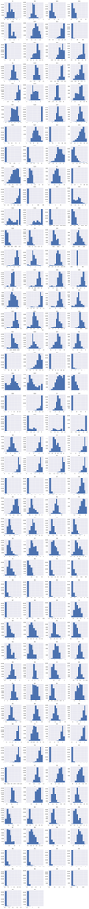

```python
# Histograms for each attribute
X_original.hist(layout=(dispRow,dispCol))
plt.show()
```

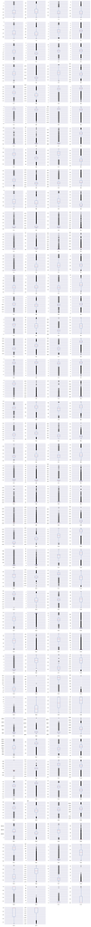

```python
# Box and Whisker plot for each attribute
X_original.plot(kind='box', subplots=True, layout=(dispRow,dispCol))
plt.show()
```

```python
# # Correlation matrix
# fig = plt.figure(figsize=(16,12))
# ax = fig.add_subplot(111)
# correlations = X_original.corr(method='pearson')
# cax = ax.matshow(correlations, vmin=-1, vmax=1)
# fig.colorbar(cax)
# plt.show()
```

```python
if notifyStatus: status_notify("Task 2 - Summarize and Visualize Data completed! "+datetime.now().strftime('%a %B %d, %Y %I:%M:%S %p'))
```

## Task 3 - Pre-process Data

```python
if notifyStatus: status_notify("Task 3 - Pre-process Data has begun! "+datetime.now().strftime('%a %B %d, %Y %I:%M:%S %p'))
```

### 3.a) Splitting Data into Training and Test Sets

```python
# Split the data further into training and test datasets
if splitDataset:
    X_train_df, X_test_df, y_train_df, y_test_df = train_test_split(X_original, y_original, test_size=splitPercentage,
                                                                    stratify=y_original, random_state=seedNum)
else:
    X_train_df, y_train_df = X_original, y_original
    X_test_df, y_test_df = X_original, y_original
print("X_train.shape: {} y_train_df.shape: {}".format(X_train_df.shape, y_train_df.shape))
print("X_test_df.shape: {} y_test_df.shape: {}".format(X_test_df.shape, y_test_df.shape))
```

```
X_train.shape: (244375, 174) y_train_df.shape: (244375,)
X_test_df.shape: (81459, 174) y_test_df.shape: (81459,)
```

### 3.b) Feature Scaling and Data Pre-Processing

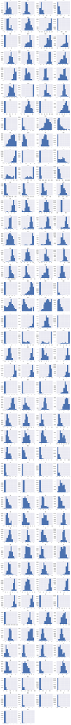

```python
# Histograms for each attribute before pre-processing
columns_to_scale = X_original.columns[X_original.dtypes == 'float64'].tolist()
X_original[columns_to_scale].hist(layout=(dispRow,dispCol))
plt.show()
```

```python
# Apply feature scaling and transformation
print('Columns to scale are:', columns_to_scale)
scaler = preprocessing.MinMaxScaler()
X_original[columns_to_scale] = scaler.fit_transform(X_original[columns_to_scale])
print(X_original.head())
```

```
Columns to scale are: ['f1', 'f2', 'f3', 'f4', 'f5', 'f6', 'f7', 'f8', 'f9', 'f10', 'f11', 'f12', 'f13', 'f14', 'f15', 'f16', 'f17', 'f18', 'f19', 'f20', 'f21', 'f22', 'f23', 'f24', 'f25', 'f26', 'f27', 'f28', 'f29', 'f30', 'f31', 'f32', 'f33', 'f34', 'f35', 'f36', 'f37', 'f38', 'f39', 'f40', 'f41',…
         f1        f2        f3  ...      f172      f173      f174
0  0.392808  0.482842  0.484525  ...  0.763244  0.111116  0.827110
1  0.421367  0.522963  0.525943  ...  0.386260  0.444442  0.405510
2  0.435363  0.539169  0.539336  ...  0.579374  0.222221  0.552415
3  0.425630  0.553129  0.541232  ...  0.522984  0.305561  0.708015
4  0.425743  0.562523  0.549866  ...  0.719598  0.111116  0.750000

[5 rows x 174 columns]
```

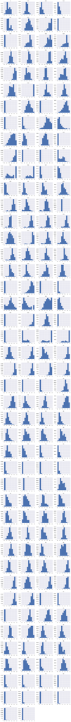

```python
# Histograms for each attribute after pre-processing
X_original[columns_to_scale].hist(layout=(dispRow,dispCol))
plt.show()
```

### 3.c) Training Data Balancing

```python
# Not applicable for this iteration of the project
```

### 3.d) Feature Selection

```python
# Not applicable for this iteration of the project
```

### 3.e) Display the Final Datasets for Model-Building

```python
# Finalize the training and testing datasets for the modeling activities
X_train = X_train_df.to_numpy()
y_train = y_train_df.ravel()
X_test = X_test_df.to_numpy()
y_test = y_test_df.ravel()
print("X_train.shape: {} y_train.shape: {}".format(X_train.shape, y_train.shape))
print("X_test.shape: {} y_test.shape: {}".format(X_test.shape, y_test.shape))
```

```
X_train.shape: (244375, 174) y_train.shape: (244375,)
X_test.shape: (81459, 174) y_test.shape: (81459,)
```

```python
if notifyStatus: status_notify("Task 3 - Pre-process Data completed! "+datetime.now().strftime('%a %B %d, %Y %I:%M:%S %p'))
```

## Task 4 - Train and Evaluate Models

```python
if notifyStatus: status_notify("Task 4 - Train and Evaluate Models has begun! "+datetime.now().strftime('%a %B %d, %Y %I:%M:%S %p'))
```

### 4.a) Set test options and evaluation metric

```python
# Set up Algorithms Spot-Checking Array
startTimeTraining = datetime.now()
startTimeModule = datetime.now()
train_models = []
train_results = []
train_model_names = []
train_metrics = []
train_models.append(('XGB', XGBClassifier(random_state=seedNum, n_jobs=n_jobs, objective='multi:softmax', num_class=7, tree_method='gpu_hist')))
```

```python
# Generate model in turn
for name, model in train_models:
	if notifyStatus: status_notify("Algorithm "+name+" modeling has begun! "+datetime.now().strftime('%a %B %d, %Y %I:%M:%S %p'))
	startTimeModule = datetime.now()
	kfold = StratifiedKFold(n_splits=n_folds, shuffle=True, random_state=seedNum)
	cv_results = cross_val_score(model, X_train, y_train, cv=kfold, scoring=scoring, n_jobs=n_jobs, verbose=1)
	train_results.append(cv_results)
	train_model_names.append(name)
	train_metrics.append(cv_results.mean())
	print("%s: %f (%f)" % (name, cv_results.mean(), cv_results.std()))
	print(model)
	print ('Model training time:', (datetime.now() - startTimeModule), '\n')
	if notifyStatus: status_notify("Algorithm "+name+" modeling completed! "+datetime.now().strftime('%a %B %d, %Y %I:%M:%S %p'))
print ('Average metrics ('+scoring+') from all models:',np.mean(train_metrics))
print ('Total training time for all models:',(datetime.now() - startTimeTraining))
```

```
[Parallel(n_jobs=1)]: Using backend SequentialBackend with 1 concurrent workers.
```

```
XGB: 0.990064 (0.000199)
XGBClassifier(base_score=0.5, booster='gbtree', colsample_bylevel=1,
              colsample_bynode=1, colsample_bytree=1, gamma=0,
              learning_rate=0.1, max_delta_step=0, max_depth=3,
              min_child_weight=1, missing=None, n_estimators=100, n_jobs=1,
              nthread=None, num_class=7, objective='multi:softmax',
              random_state=888, reg_alpha=0, reg_lambda=1, scale_pos_weight=1,
              seed=None, silent=None, subsample=1, tree_method='gpu_hist',
              verbosity=1)
Model training time: 0:00:34.034119

Average metrics (accuracy) from all models: 0.9900644501278772
Total training time for all models: 0:00:34.049672
```

```
[Parallel(n_jobs=1)]: Done   5 out of   5 | elapsed:   34.0s finished
```

### 4.b) Spot-checking baseline algorithms

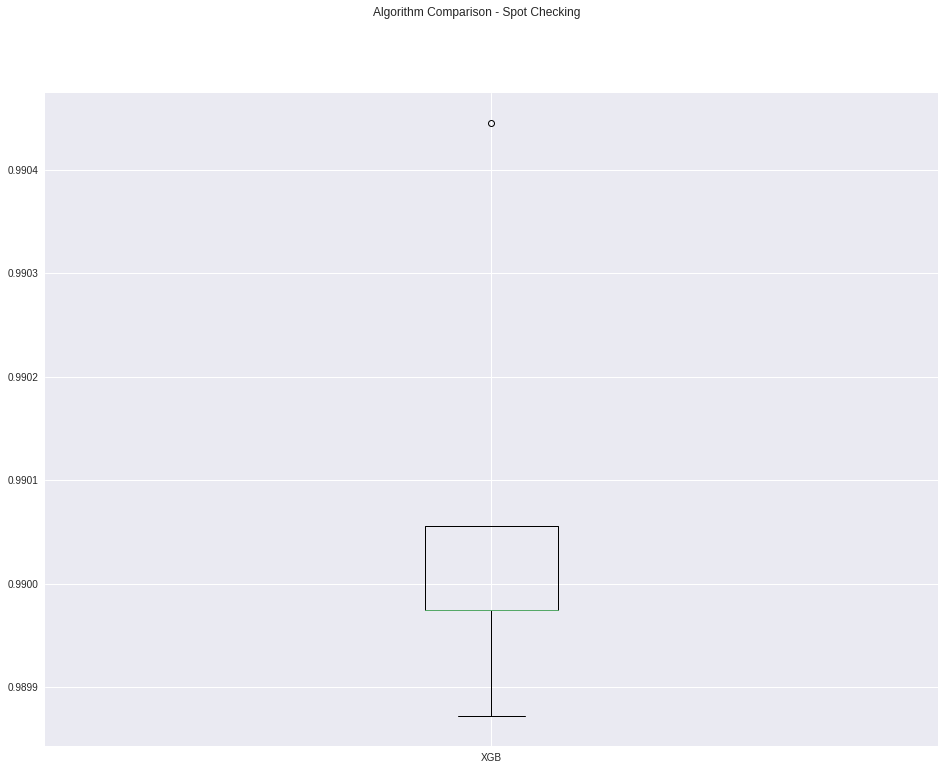

```python
fig = plt.figure(figsize=(16,12))
fig.suptitle('Algorithm Comparison - Spot Checking')
ax = fig.add_subplot(111)
plt.boxplot(train_results)
ax.set_xticklabels(train_model_names)
plt.show()
```

```python
if notifyStatus: status_notify("Task 4 - Train and Evaluate Models completed! "+datetime.now().strftime('%a %B %d, %Y %I:%M:%S %p'))
```

## Task 5 - Fine-tune and Improve Models

```python
if notifyStatus: status_notify("Task 5 - Fine-tune and Improve Models has begun! "+datetime.now().strftime('%a %B %d, %Y %I:%M:%S %p'))
```

### 5.a) Algorithm Tuning

```python
# Set up the comparison array
tune_results = []
tune_model_names = []
```

```python
# Tuning XGBoost n_estimators, max_depth, and min_child_weight parameters
startTimeModule = datetime.now()
if notifyStatus: status_notify("Algorithm tuning iteration #1 has begun! "+datetime.now().strftime('%a %B %d, %Y %I:%M:%S %p'))

tune_model1 = XGBClassifier(random_state=seedNum, n_jobs=n_jobs, objective='multi:softmax', num_class=7, tree_method='gpu_hist')
tune_model_names.append('XGB_1')
paramGrid1 = dict(n_estimators=range(500,1001,100), max_depth=np.array([3,6,9]), min_child_weight=np.array([1,2,3]))

kfold = StratifiedKFold(n_splits=n_folds, shuffle=True, random_state=seedNum)
grid1 = GridSearchCV(estimator=tune_model1, param_grid=paramGrid1, scoring=scoring, cv=kfold, verbose=2)
grid_result1 = grid1.fit(X_train, y_train)

print("Best: %f using %s" % (grid_result1.best_score_, grid_result1.best_params_))
tune_results.append(grid_result1.cv_results_['mean_test_score'])
means = grid_result1.cv_results_['mean_test_score']
stds = grid_result1.cv_results_['std_test_score']
params = grid_result1.cv_results_['params']
for mean, stdev, param in zip(means, stds, params):
    print("%f (%f) with: %r" % (mean, stdev, param))
print ('Model training time:',(datetime.now() - startTimeModule))
if notifyStatus: status_notify("Algorithm tuning iteration #1 completed! "+datetime.now().strftime('%a %B %d, %Y %I:%M:%S %p'))
```

```
Fitting 5 folds for each of 54 candidates, totalling 270 fits
[CV] max_depth=3, min_child_weight=1, n_estimators=500 ...............
```

```
[Parallel(n_jobs=1)]: Using backend SequentialBackend with 1 concurrent workers.
```

```
[CV]  max_depth=3, min_child_weight=1, n_estimators=500, total=  30.2s
[CV] max_depth=3, min_child_weight=1, n_estimators=500 ...............
```

```
[Parallel(n_jobs=1)]: Done   1 out of   1 | elapsed:   30.2s remaining:    0.0s
```

[output not shown]

[output cut: 482 more lines]

```
[CV]  max_depth=9, min_child_weight=3, n_estimators=900, total= 1.0min
[CV] max_depth=9, min_child_weight=3, n_estimators=900 ...............
[CV]  max_depth=9, min_child_weight=3, n_estimators=900, total=  59.9s
[CV] max_depth=9, min_child_weight=3, n_estimators=900 ...............
[CV]  max_depth=9, min_child_weight=3, n_estimators=900, total= 1.0min
[CV] max_depth=9, min_child_weight=3, n_estimators=1000 ..............
[CV]  max_depth=9, min_child_weight=3, n_estimators=1000, total= 1.1min
[CV] max_depth=9, min_child_weight=3, n_estimators=1000 ..............
[CV]  max_depth=9, min_child_weight=3, n_estimators=1000, total= 1.1min
[CV] max_depth=9, min_child_weight=3, n_estimators=1000 ..............
[CV]  max_depth=9, min_child_weight=3, n_estimators=1000, total= 1.1min
[CV] max_depth=9, min_child_weight=3, n_estimators=1000 ..............
[CV]  max_depth=9, min_child_weight=3, n_estimators=1000, total= 1.1min
[CV] max_depth=9, min_child_weight=3, n_estimators=1000 ..............
[CV]  max_depth=9, min_child_weight=3, n_estimators=1000, total= 1.1min
```

```
[Parallel(n_jobs=1)]: Done 270 out of 270 | elapsed: 224.4min finished
```

```
Best: 0.998154 using {'max_depth': 6, 'min_child_weight': 1, 'n_estimators': 900}
0.996874 (0.000119) with: {'max_depth': 3, 'min_child_weight': 1, 'n_estimators': 500}
0.997189 (0.000143) with: {'max_depth': 3, 'min_child_weight': 1, 'n_estimators': 600}
0.997451 (0.000161) with: {'max_depth': 3, 'min_child_weight': 1, 'n_estimators': 700}
0.997573 (0.000125) with: {'max_depth': 3, 'min_child_weight': 1, 'n_estimators': 800}
0.997684 (0.000148) with: {'max_depth': 3, 'min_child_weight': 1, 'n_estimators': 900}
0.997770 (0.000145) with: {'max_depth': 3, 'min_child_weight': 1, 'n_estimators': 1000}
0.996910 (0.000148) with: {'max_depth': 3, 'min_child_weight': 2, 'n_estimators': 500}
0.997213 (0.000146) with: {'max_depth': 3, 'min_child_weight': 2, 'n_estimators': 600}
0.997430 (0.000096) with: {'max_depth': 3, 'min_child_weight': 2, 'n_estimators': 700}
0.997602 (0.000135) with: {'max_depth': 3, 'min_child_weight': 2, 'n_estimators': 800}
0.997680 (0.000136) with: {'max_depth': 3, 'min_child_weight': 2, 'n_estimators': 900}
0.997745 (0.000157) with: {'max_depth': 3, 'min_child_weight': 2, 'n_estimators': 1000}
0.996915 (0.000129) with: {'max_depth': 3, 'min_child_weight': 3, 'n_estimators': 500}
0.997131 (0.000113) with: {'max_depth': 3, 'min_child_weight': 3, 'n_estimators': 600}
0.997336 (0.000143) with: {'max_depth': 3, 'min_child_weight': 3, 'n_estimators': 700}
0.997512 (0.000182) with: {'max_depth': 3, 'min_child_weight': 3, 'n_estimators': 800}
0.997594 (0.000169) with: {'max_depth': 3, 'min_child_weight': 3, 'n_estimators': 900}
0.997717 (0.000142) with: {'max_depth': 3, 'min_child_weight': 3, 'n_estimators': 1000}
0.997999 (0.000106) with: {'max_depth': 6, 'min_child_weight': 1, 'n_estimators': 500}
0.998056 (0.000088) with: {'max_depth': 6, 'min_child_weight': 1, 'n_estimators': 600}
0.998097 (0.000099) with: {'max_depth': 6, 'min_child_weight': 1, 'n_estimators': 700}
0.998126 (0.000102) with: {'max_depth': 6, 'min_child_weight': 1, 'n_estimators': 800}
0.998154 (0.000108) with: {'max_depth': 6, 'min_child_weight': 1, 'n_estimators': 900}
0.998142 (0.000126) with: {'max_depth': 6, 'min_child_weight': 1, 'n_estimators': 1000}
0.997864 (0.000117) with: {'max_depth': 6, 'min_child_weight': 2, 'n_estimators': 500}
0.997917 (0.000093) with: {'max_depth': 6, 'min_child_weight': 2, 'n_estimators': 600}
0.997987 (0.000062) with: {'max_depth': 6, 'min_child_weight': 2, 'n_estimators': 700}
0.997995 (0.000068) with: {'max_depth': 6, 'min_child_weight': 2, 'n_estimators': 800}
0.998032 (0.000078) with: {'max_depth': 6, 'min_child_weight': 2, 'n_estimators': 900}
0.998052 (0.000065) with: {'max_depth': 6, 'min_child_weight': 2, 'n_estimators': 1000}
0.997917 (0.000068) with: {'max_depth': 6, 'min_child_weight': 3, 'n_estimators': 500}
0.997966 (0.000086) with: {'max_depth': 6, 'min_child_weight': 3, 'n_estimators': 600}
0.997970 (0.000078) with: {'max_depth': 6, 'min_child_weight': 3, 'n_estimators': 700}
0.998024 (0.000098) with: {'max_depth': 6, 'min_child_weight': 3, 'n_estimators': 800}
0.998040 (0.000070) with: {'max_depth': 6, 'min_child_weight': 3, 'n_estimators': 900}
0.998048 (0.000099) with: {'max_depth': 6, 'min_child_weight': 3, 'n_estimators': 1000}
0.997696 (0.000075) with: {'max_depth': 9, 'min_child_weight': 1, 'n_estimators': 500}
0.997753 (0.000088) with: {'max_depth': 9, 'min_child_weight': 1, 'n_estimators': 600}
0.997807 (0.000083) with: {'max_depth': 9, 'min_child_weight': 1, 'n_estimators': 700}
0.997811 (0.000084) with: {'max_depth': 9, 'min_child_weight': 1, 'n_estimators': 800}
0.997827 (0.000080) with: {'max_depth': 9, 'min_child_weight': 1, 'n_estimators': 900}
0.997852 (0.000104) with: {'max_depth': 9, 'min_child_weight': 1, 'n_estimators': 1000}
0.997790 (0.000165) with: {'max_depth': 9, 'min_child_weight': 2, 'n_estimators': 500}
0.997827 (0.000163) with: {'max_depth': 9, 'min_child_weight': 2, 'n_estimators': 600}
0.997868 (0.000159) with: {'max_depth': 9, 'min_child_weight': 2, 'n_estimators': 700}
0.997880 (0.000172) with: {'max_depth': 9, 'min_child_weight': 2, 'n_estimators': 800}
0.997913 (0.000168) with: {'max_depth': 9, 'min_child_weight': 2, 'n_estimators': 900}
0.997946 (0.000157) with: {'max_depth': 9, 'min_child_weight': 2, 'n_estimators': 1000}
0.997774 (0.000139) with: {'max_depth': 9, 'min_child_weight': 3, 'n_estimators': 500}
0.997807 (0.000144) with: {'max_depth': 9, 'min_child_weight': 3, 'n_estimators': 600}
0.997835 (0.000149) with: {'max_depth': 9, 'min_child_weight': 3, 'n_estimators': 700}
0.997868 (0.000159) with: {'max_depth': 9, 'min_child_weight': 3, 'n_estimators': 800}
0.997888 (0.000158) with: {'max_depth': 9, 'min_child_weight': 3, 'n_estimators': 900}
0.997893 (0.000146) with: {'max_depth': 9, 'min_child_weight': 3, 'n_estimators': 1000}
Model training time: 3:45:40.865844
```

```python
# Tuning XGBoost subsample and colsample_bytree parameters
startTimeModule = datetime.now()
if notifyStatus: status_notify("Algorithm tuning iteration #2 has begun! "+datetime.now().strftime('%a %B %d, %Y %I:%M:%S %p'))

tune_model1 = XGBClassifier(n_estimators=900, max_depth=6, min_child_weight=1, random_state=seedNum, n_jobs=n_jobs, objective='multi:softmax', num_class=7, tree_method='gpu_hist')
tune_model_names.append('XGB_2')
paramGrid1 = dict(subsample=np.array([0.6,0.7,0.8,0.9,1.0]), colsample_bytree=np.array([0.6,0.7,0.8,0.9,1.0]))

kfold = StratifiedKFold(n_splits=n_folds, shuffle=True, random_state=seedNum)
grid1 = GridSearchCV(estimator=tune_model1, param_grid=paramGrid1, scoring=scoring, cv=kfold, verbose=2)
grid_result1 = grid1.fit(X_train, y_train)

print("Best: %f using %s" % (grid_result1.best_score_, grid_result1.best_params_))
tune_results.append(grid_result1.cv_results_['mean_test_score'])
means = grid_result1.cv_results_['mean_test_score']
stds = grid_result1.cv_results_['std_test_score']
params = grid_result1.cv_results_['params']
for mean, stdev, param in zip(means, stds, params):
    print("%f (%f) with: %r" % (mean, stdev, param))
print ('Model training time:',(datetime.now() - startTimeModule))
if notifyStatus: status_notify("Algorithm tuning iteration #2 completed! "+datetime.now().strftime('%a %B %d, %Y %I:%M:%S %p'))
```

```
Fitting 5 folds for each of 25 candidates, totalling 125 fits
[CV] colsample_bytree=0.6, subsample=0.6 .............................
```

```
[Parallel(n_jobs=1)]: Using backend SequentialBackend with 1 concurrent workers.
```

```
[CV] .............. colsample_bytree=0.6, subsample=0.6, total= 1.1min
[CV] colsample_bytree=0.6, subsample=0.6 .............................
```

```
[Parallel(n_jobs=1)]: Done   1 out of   1 | elapsed:  1.1min remaining:    0.0s
```

[output not shown]

[output cut: 192 more lines]

```
[CV] .............. colsample_bytree=1.0, subsample=0.9, total= 1.1min
[CV] colsample_bytree=1.0, subsample=0.9 .............................
[CV] .............. colsample_bytree=1.0, subsample=0.9, total= 1.0min
[CV] colsample_bytree=1.0, subsample=0.9 .............................
[CV] .............. colsample_bytree=1.0, subsample=0.9, total= 1.1min
[CV] colsample_bytree=1.0, subsample=1.0 .............................
[CV] .............. colsample_bytree=1.0, subsample=1.0, total= 1.1min
[CV] colsample_bytree=1.0, subsample=1.0 .............................
[CV] .............. colsample_bytree=1.0, subsample=1.0, total= 1.1min
[CV] colsample_bytree=1.0, subsample=1.0 .............................
[CV] .............. colsample_bytree=1.0, subsample=1.0, total= 1.0min
[CV] colsample_bytree=1.0, subsample=1.0 .............................
[CV] .............. colsample_bytree=1.0, subsample=1.0, total= 1.0min
[CV] colsample_bytree=1.0, subsample=1.0 .............................
[CV] .............. colsample_bytree=1.0, subsample=1.0, total= 1.0min
```

```
[Parallel(n_jobs=1)]: Done 125 out of 125 | elapsed: 132.8min finished
```

```
Best: 0.998240 using {'colsample_bytree': 0.8, 'subsample': 0.8}
0.998085 (0.000096) with: {'colsample_bytree': 0.6, 'subsample': 0.6}
0.998195 (0.000101) with: {'colsample_bytree': 0.6, 'subsample': 0.7}
0.998179 (0.000099) with: {'colsample_bytree': 0.6, 'subsample': 0.8}
0.998212 (0.000102) with: {'colsample_bytree': 0.6, 'subsample': 0.9}
0.998179 (0.000091) with: {'colsample_bytree': 0.6, 'subsample': 1.0}
0.998159 (0.000145) with: {'colsample_bytree': 0.7, 'subsample': 0.6}
0.998179 (0.000099) with: {'colsample_bytree': 0.7, 'subsample': 0.7}
0.998191 (0.000118) with: {'colsample_bytree': 0.7, 'subsample': 0.8}
0.998183 (0.000095) with: {'colsample_bytree': 0.7, 'subsample': 0.9}
0.998171 (0.000096) with: {'colsample_bytree': 0.7, 'subsample': 1.0}
0.998142 (0.000111) with: {'colsample_bytree': 0.8, 'subsample': 0.6}
0.998154 (0.000077) with: {'colsample_bytree': 0.8, 'subsample': 0.7}
0.998240 (0.000104) with: {'colsample_bytree': 0.8, 'subsample': 0.8}
0.998220 (0.000086) with: {'colsample_bytree': 0.8, 'subsample': 0.9}
0.998093 (0.000088) with: {'colsample_bytree': 0.8, 'subsample': 1.0}
0.998171 (0.000083) with: {'colsample_bytree': 0.9, 'subsample': 0.6}
0.998134 (0.000100) with: {'colsample_bytree': 0.9, 'subsample': 0.7}
0.998204 (0.000030) with: {'colsample_bytree': 0.9, 'subsample': 0.8}
0.998183 (0.000061) with: {'colsample_bytree': 0.9, 'subsample': 0.9}
0.998097 (0.000099) with: {'colsample_bytree': 0.9, 'subsample': 1.0}
0.998114 (0.000066) with: {'colsample_bytree': 1.0, 'subsample': 0.6}
0.998089 (0.000053) with: {'colsample_bytree': 1.0, 'subsample': 0.7}
0.998171 (0.000097) with: {'colsample_bytree': 1.0, 'subsample': 0.8}
0.998163 (0.000088) with: {'colsample_bytree': 1.0, 'subsample': 0.9}
0.998154 (0.000108) with: {'colsample_bytree': 1.0, 'subsample': 1.0}
Model training time: 2:14:08.344529
```

### 5.b) Compare Algorithms After Tuning

[figure not shown]

```python
fig = plt.figure(figsize=(16,12))
fig.suptitle('Algorithm Comparison - Post Tuning')
ax = fig.add_subplot(111)
plt.boxplot(tune_results)
ax.set_xticklabels(tune_names)
plt.show()
```

```python
if notifyStatus: status_notify("Task 5 - Fine-tune and Improve Models completed! "+datetime.now().strftime('%a %B %d, %Y %I:%M:%S %p'))
```

## Task 6 - Finalize Model and Present Analysis

```python
if notifyStatus: status_notify("Task 6 - Finalize Model and Present Analysis has begun! "+datetime.now().strftime('%a %B %d, %Y %I:%M:%S %p'))
```

### 6.a) Measure predictions from the test dataset

```python
test_model1 = XGBClassifier(n_estimators=900, max_depth=6, min_child_weight=1, subsample=0.8, colsample_bytree=0.8, random_state=seedNum, n_jobs=n_jobs, objective='multi:softmax', num_class=7, tree_method='gpu_hist')
test_model1.fit(X_train, y_train)
predictions1 = test_model1.predict(X_test)
print('Accuracy Score:', accuracy_score(y_test, predictions1))
print(confusion_matrix(y_test, predictions1))
print(classification_report(y_test, predictions1))
print(test_model1)
```

```
Accuracy Score: 0.9984532095901005
[[ 9775     1     2     9     0     2     2]
 [    0   897     0     2     0     0     0]
 [    0     1 18905     3     3     6     0]
 [    4     0     6 18494     7     6     0]
 [    0     0     3    18 11733    24     1]
 [    0     0     1     5    14 21246     3]
 [    2     0     1     0     0     0   283]]
              precision    recall  f1-score   support

           1       1.00      1.00      1.00      9791
           2       1.00      1.00      1.00       899
           3       1.00      1.00      1.00     18918
           4       1.00      1.00      1.00     18517
           5       1.00      1.00      1.00     11779
           6       1.00      1.00      1.00     21269
           7       0.98      0.99      0.98       286

    accuracy                           1.00     81459
   macro avg       1.00      1.00      1.00     81459
weighted avg       1.00      1.00      1.00     81459

XGBClassifier(base_score=0.5, booster='gbtree', colsample_bylevel=1,
              colsample_bynode=1, colsample_bytree=0.8, gamma=0,
              learning_rate=0.1, max_delta_step=0, max_depth=6,
              min_child_weight=1, missing=None, n_estimators=900, n_jobs=1,
              nthread=None, num_class=7, objective='multi:softprob',
              random_state=888, reg_alpha=0, reg_lambda=1, scale_pos_weight=1,
              seed=None, silent=None, subsample=0.8, tree_method='gpu_hist',
              verbosity=1)
```

### 6.b) Create a standalone model using all available data

```python
# Combining the training and testing datasets to form the complete dataset that will be used for training the final model
# X_complete = np.vstack((X_train, X_test))
# y_complete = np.concatenate((y_train, y_test))
# print("X_complete.shape: {} y_complete.shape: {}".format(X_complete.shape, y_complete.shape))
# final_model = test_model1.fit(X_complete, y_complete)
# print(final_model)
```

### 6.c) Save the final model for later use

```python
# modelName = 'FinalModel_MultiClass.sav'
# dump(final_model, modelName)
```

```python
if notifyStatus: status_notify("Task 6 - Finalize Model and Present Analysis completed! "+datetime.now().strftime('%a %B %d, %Y %I:%M:%S %p'))
```

```python
print ('Total time for the script:',(datetime.now() - startTimeScript))
```

```
Total time for the script: 12:37:52.001399
```